# Лабораторная работа №7

Командная оболочка Midnight Commander

Ежова А. М.

Российский университет дружбы народов, Москва, Россия

Факультет физико-математических и естесвенных наук

24 марта 2023

# Информация

## Докладчик

- Ежова Алиса Михайловна
- студентка НБИбд-01-22
- Российский университет дружбы народов
- https://github.com/AlisaEzhova

[figure not shown]

# Вводная часть

## Актуальность

- Данная лабораторная работа актуальна для студентов, кто хочет освоить основные возможности командной оболочки Midnight Commander.

## Цели и задачи

- Освоить основные возможности командной оболочки Midnight Commander. Приобрести навыки практической работы по просмотру каталогов и файлов; манипуляций с ними.

## Материалы и методы

- Процессор `pandoc` для входного формата Markdown
- Результирующие форматы
  - `pdf`
  - `html`
- Автоматизация процесса создания: `Makefile`

# Создание презентации

## Процессор `pandoc`

- Pandoc: преобразователь текстовых файлов
- Сайт: https://pandoc.org/
- Репозиторий: https://github.com/jgm/pandoc

## Формат `pdf`

- Использование LaTeX
- Пакет для презентации: beamer
- Тема оформления: `metropolis`

## Код для формата `pdf`

```yaml
slide_level: 2
aspectratio: 169
section-titles: true
theme: metropolis
```

## Формат `html`

- Используется фреймворк [reveal.js](https://revealjs.com/)
- Используется [тема](https://revealjs.com/themes/) `beige`

## Код для формата `html`

- Тема задаётся в файле `Makefile`

```
REVEALJS_THEME = beige
```

## Содержание исследования

1. Изучила информацию о mc, вызвав в командной строке man mc:

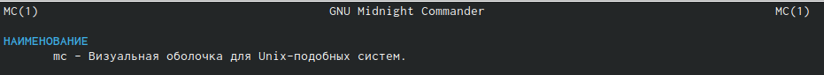

Информация о mc

2. Запустила из командной строки mc, изучила его структуру и меню:

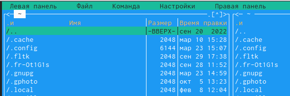

Командная строка mc

3. Выполнила несколько операций в mc, используя управляющие клавиши (операции с панелями; выделение/отмена выделения файлов, копирование/перемещение файлов, получение информации о размере и правах доступа на файлы и/или каталоги и т.п.)

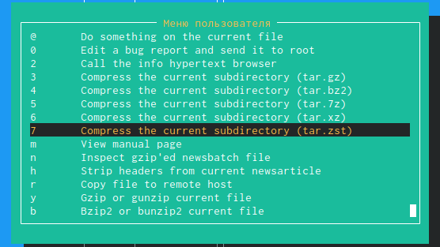

Операции в mc

4. Используя возможности подменю Файл , выполнила:
- просмотр содержимого текстового файла;

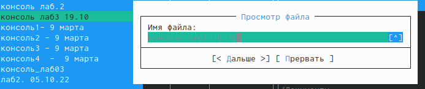

Просмотр

[figure not shown]

Просмотр

- создание каталога;

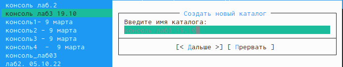

Новый каталог

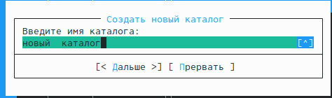

Новый каталог

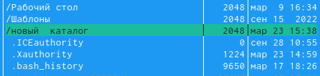

Новый каталог

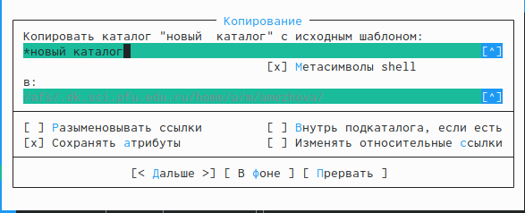

Копирование

5. С помощью соответствующих средств подменю Команда осуществите:
- поиск в файловой системе файла с заданными условиями (например, файла с расширением .c или .cpp, содержащего строку main);

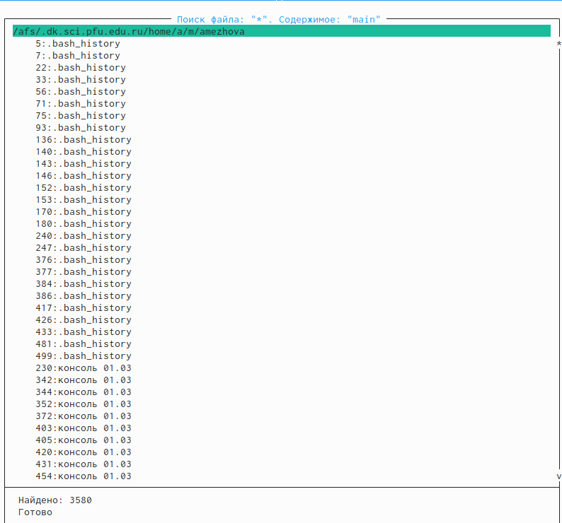

Поиск

- выбор и повторение одной из предыдущих команд;

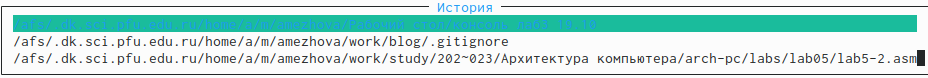

Выбор команды

6. Создала текстовый файл text.txt:

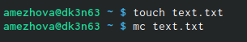

Новый файл

7. Открыла этот файл с помощью встроенного в mc редактора:

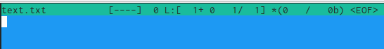

Открытый файл

8. Вставила в открытый файл небольшой фрагмент текста, скопированный из Интернета:

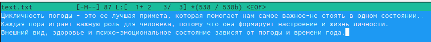

Текст

9. Проделайте с текстом следующие манипуляции, используя горячие клавиши:
- Удалила строку текста:

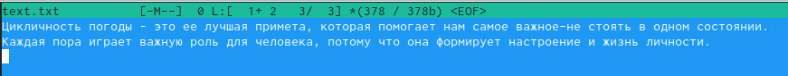

Текст

- Выделила фрагмент текста и скопировала его на новую строку:

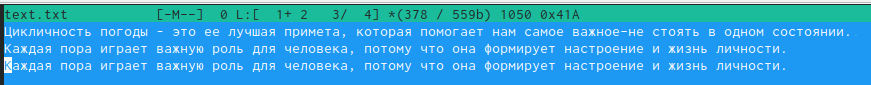

Текст

- Выделила фрагмент текста и перенесла его на новую строку:

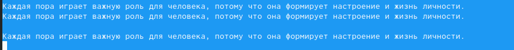

Текст

- Сохранила файл:

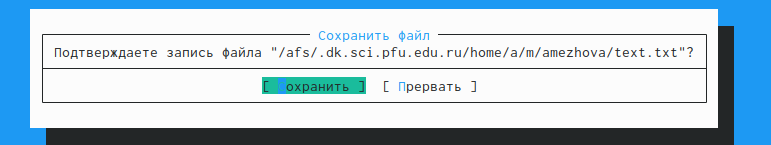

Текст

- Отменила последнее действие:

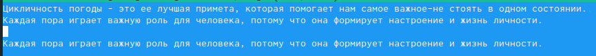

Текст

- Перешла в конец файла (нажав комбинацию клавиш) и написала некоторый текст:

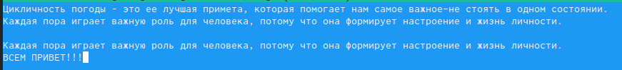

Текст

- Перешла в начало файла (нажав комбинацию клавиш) и написала некоторый текст:

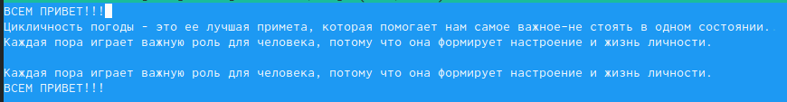

Текст

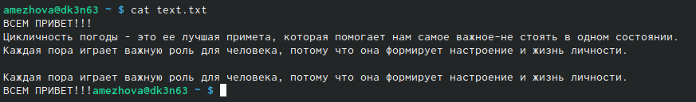

Открытый файл

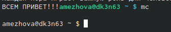

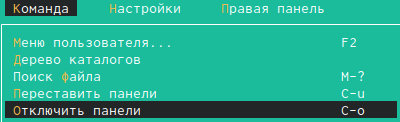

## Итоговый слайд

- В ходе выполнения лабораторной работы №7 я освоила основные возможности командной оболочки Midnight Commander. Приобрела навыки практической работы по просмотру каталогов и файлов; манипуляций с ними.